# Identify Fraud from Enron Email

## Y. Jeremy Dai

This is an effort to practice my skills learnt from Intro to Machine Learning(Udacity) by building an algorithm to identify Enron Employees who may have committed fraud based on the public Enron financial and email dataset.

## Intro

One of largest companies in the US, Enron, collapsed into bankruptcy all of a sudden in 2000. This project is to build a person of interest (POI) identifier based on financial and email data made public as a result of the Enron scandal. A list of POI, who were indicted, reached a settlement or plea deal with the government, or testified in exchange for prosecution immunity, is provided by Udacity for supervised machine learning.

## Exploring the data

```python
import sys
import pickle
import numpy
import seaborn as sns
import matplotlib.pyplot as plt
import pandas as pd
import numpy as np
from time import time
%matplotlib inline
import tester

sys.path.append("../tools/")

#from feature_format import featureFormat, targetFeatureSplit


### Load the dictionary containing the dataset
with open("final_project_dataset.pkl", "r") as data_file:
    data_dict = pickle.load(data_file)

### Data Exploration
### Check number of samples and POI
print 'Number of Poeple in the sample: ',len(data_dict)

n = 0
for person_name in data_dict:
    if data_dict[person_name]["poi"]==1:
        n+=1
print 'Number of POI: ',n

### Create a dataframe based on data_dict, drop the 'email_address' column
enron=pd.DataFrame.from_dict(data_dict, orient='index')
enron=enron.drop('email_address',axis=1)
print 'There are',enron.shape[1],'features available.'
```

```
Number of Poeple in the sample:  146
Number of POI:  18
There are 20 features available.
```

```python
### Check the NaN values
enron=enron.replace('NaN',np.nan)
enron_nan=enron.isnull().sum()
enron_nan.sort_values(ascending=False, inplace=True)
print '\nTotal number of NaN values in the dataset:',enron_nan.sum()
print '\nTop five features with most NaN values in the dataset:'
print enron_nan[:5]
```

```
Total number of NaN values in the dataset: 1323

Top five features with most NaN values in the dataset:
loan_advances                142
director_fees                129
restricted_stock_deferred    128
deferral_payments            107
deferred_income               97
dtype: int64
```

```python
for f in enron_nan[:5].index:
    yes = enron[enron[f].isnull()]['poi'].sum()
    no = enron[~enron[f].isnull()]['poi'].sum()
    print f,'is NaN: there are',yes,'POI'
    print f,'is NOT NaN: there are',no,'POI'
    print 'The ratio of POI in NaN value is', float(yes)/(yes+no)
    print 'The ratio of NaN for',f,'is',float(enron_nan[f])/146,'\n'
```

```
loan_advances is NaN: there are 17 POI
loan_advances is NOT NaN: there are 1 POI
The ratio of POI in NaN value is 0.944444444444
The ratio of NaN for loan_advances is 0.972602739726

director_fees is NaN: there are 18 POI
director_fees is NOT NaN: there are 0 POI
The ratio of POI in NaN value is 1.0
The ratio of NaN for director_fees is 0.883561643836

restricted_stock_deferred is NaN: there are 18 POI
restricted_stock_deferred is NOT NaN: there are 0 POI
The ratio of POI in NaN value is 1.0
The ratio of NaN for restricted_stock_deferred is 0.876712328767

deferral_payments is NaN: there are 13 POI
deferral_payments is NOT NaN: there are 5 POI
The ratio of POI in NaN value is 0.722222222222
The ratio of NaN for deferral_payments is 0.732876712329

deferred_income is NaN: there are 7 POI
deferred_income is NOT NaN: there are 11 POI
The ratio of POI in NaN value is 0.388888888889
The ratio of NaN for deferred_income is 0.664383561644
```

For the top five features with most NaN values in the dataset, we cannot simply remove them since if POI is with NaN value or not for some of these feature does not seem random. We will replace them with 0.

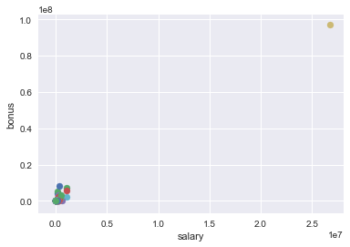

```
The sample with biggest salary is: ['TOTAL']
```

```python
### use visulization to find outliers
enron.fillna(0,inplace=True)

for i, j in enron[['salary','bonus']].values:
    plt.scatter(i,j)

plt.xlabel('salary')
plt.ylabel('bonus')
plt.show()

print 'The sample with biggest salary is:', list(enron.sort_values(ascending=False, by='salary')[:1].index)
```

This is definitely a outlier are we are going to remove it.

```python
### Remove the clear outlier : 'Total'
try:
    enron=enron.drop('TOTAL')
except:
    pass
```

## Create new features

```python
### Reset columns
features_list = ['poi',
        'salary','bonus', 'deferral_payments', 'deferred_income', 'director_fees',
        'expenses', 'loan_advances', 'long_term_incentive', 'other', 'total_payments',
        'restricted_stock', 'restricted_stock_deferred',
        'exercised_stock_options','total_stock_value',
        'to_messages','from_messages','shared_receipt_with_poi',
        'from_poi_to_this_person', 'from_this_person_to_poi',]

enron=enron.reindex_axis(features_list, axis=1)

print 'Create a new feature summing up payments and stocks'
enron['total_finance']=enron['total_payments']+enron['total_stock_value']

print 'Create a new feature of the percentage of person\'s emails to POI to all sent emails'
enron['p_poi_to_msg']=1.0*enron['from_this_person_to_poi']/enron['to_messages']

print 'Create a new feature of the percentage of person\'s emails from POI to all received emails'
enron['p_poi_from_msg']=1.0*enron['from_poi_to_this_person']/enron['from_messages']

enron=enron.fillna(0)

### check the columns
enron.iloc[:5, 20:23]

### update the feature list
features_list = list(enron.columns)
```

```
Create a new feature summing up payments and stocks
Create a new feature of the percentage of person's emails to POI to all sent emails
Create a new feature of the percentage of person's emails from POI to all received emails
```

```python
enron[enron['total_finance']==0]
```

|  | poi | salary | bonus | deferral_payments | deferred_income | director_fees | expenses | loan_advances | long_term_incentive | other | ... | exercised_stock_options | total_stock_value | to_messages | from_messages | shared_receipt_with_poi | from_poi_to_this_person | from_this_person_to_poi | total_finance | p_poi_to_msg | p_poi_from_msg |
| --- | --- | --- | --- | --- | --- | --- | --- | --- | --- | --- | --- | --- | --- | --- | --- | --- | --- | --- | --- | --- | --- |
| CHAN RONNIE | False | 0.0 | 0.0 | 0.0 | -98784.0 | 98784.0 | 0.0 | 0.0 | 0.0 | 0.0 | ... | 0.0 | 0.0 | 0.0 | 0.0 | 0.0 | 0.0 | 0.0 | 0.0 | 0.0 | 0.0 |
| LOCKHART EUGENE E | False | 0.0 | 0.0 | 0.0 | 0.0 | 0.0 | 0.0 | 0.0 | 0.0 | 0.0 | ... | 0.0 | 0.0 | 0.0 | 0.0 | 0.0 | 0.0 | 0.0 | 0.0 | 0.0 | 0.0 |
| POWERS WILLIAM | False | 0.0 | 0.0 | 0.0 | -17500.0 | 17500.0 | 0.0 | 0.0 | 0.0 | 0.0 | ... | 0.0 | 0.0 | 653.0 | 26.0 | 12.0 | 0.0 | 0.0 | 0.0 | 0.0 | 0.0 |

3 rows × 23 columns

There is a row with no entry:'LOCKHART EUGENE E'. It will be removed.

```python
### Remove 'LOCKHART EUGENE E' Row

try:
    enron=enron.drop('LOCKHART EUGENE E')
except:
    pass

### Check other outliers
ave=enron['salary'].mean()
poi_h_salary=enron['poi'][enron['salary']>ave]

print '{} of {} people whose salary is larger than the average are POI'.format(sum(poi_h_salary), len(poi_h_salary))
```

```
16 of 79 people whose salary is larger than the average are POI
```

We cannot simply remove these people. It seems that POI tends to have salary higher than the average.

Next, we will select features for training.

## Select features

```python
### Test the created features use Decision Tree

from sklearn.metrics import classification_report
from sklearn.metrics import confusion_matrix
from sklearn import tree
from sklearn.cross_validation import train_test_split

features=enron.iloc[:,1:].values
labels=enron.iloc[:,:1].values

### Split the data into training and test
print '70% of data is used for training and the remaining 30% is used for test.'
feature_train, feature_test, label_train, label_test =\
train_test_split(features, labels,test_size=0.3, random_state=42)

clf = tree.DecisionTreeClassifier(random_state = 39)

### Create the function to train and output the evaluation results
def test(clf):
    clf.fit(feature_train, label_train)
    label_pred = clf.predict(feature_test)
    ### Quantitative evaluation of the model quality on the test set
    print 'The evaluation results:'
    print classification_report(label_test, label_pred,target_names=['Not POI','POI'])
    print confusion_matrix(label_test, label_pred)

test(clf)

print '\nThe important features are:'
fea=clf.feature_importances_
n=0
for f in fea:
    if f>0.0:
        print f,features_list[n]
    n+=1
```

```
70% of data is used for training and the remaining 30% is used for test.
The evaluation results:
             precision    recall  f1-score   support

    Not POI       0.90      0.95      0.92        39
        POI       0.33      0.20      0.25         5

avg / total       0.84      0.86      0.85        44

[[37  2]
 [ 4  1]]

The important features are:
0.220426513942 salary
0.136188597727 deferral_payments
0.105863661155 director_fees
0.132625994695 loan_advances
0.168173897756 total_payments
0.0736811081639 restricted_stock_deferred
0.0757862826828 to_messages
0.0114676611954 from_poi_to_this_person
0.0757862826828 p_poi_to_msg
```

Since we have an imbalanced sample with much more non-POI than POI, both recall and precision rate are important in evaluation.

In this study, we will utilize the classification_report and confusion_matrix to generate precision rate, recall rate.

- Recall = True Positive / (True Positive + False Negative).
- Precision=True Positive / (True Positive + False Positive).

For the above test: Recall:

- Out of 5 POI, only 1 POI were correctly classified correctly.
- Out of 39 Non-POI, 37 of them were 'recalled' from the dataset.

Precision:

- Out of 3 ‘selected’ POI, only 1 of them are true POI.
- Out of 41 ‘selected’ non-POI, only 37 of them are true non-POI.

Depending on the random_state, sometimes the new created features are the important ones while sometimes they are not. We will try Naive Bayes next.

```python
### Naive_Bayes
from sklearn.naive_bayes import GaussianNB
clf=GaussianNB()

print 'Without new created features'

### Limit the features
features=enron.iloc[:,1:20].values
labels=enron.iloc[:,:1].values

feature_train, feature_test, label_train, label_test =\
train_test_split(features, labels,test_size=0.3, random_state=42)

test(clf)

print '\nWith new created features:'

# Change the features list back with new added features
features=enron.iloc[:,1:].values
labels=enron.iloc[:,:1].values

feature_train, feature_test, label_train, label_test =\
train_test_split(features, labels,test_size=0.3, random_state=42)

test(clf)
```

```
Without new created features
The evaluation results:
             precision    recall  f1-score   support

    Not POI       0.93      0.95      0.94        39
        POI       0.50      0.40      0.44         5

avg / total       0.88      0.89      0.88        44

[[37  2]
 [ 3  2]]

With new created features:
The evaluation results:
             precision    recall  f1-score   support

    Not POI       0.93      0.97      0.95        39
        POI       0.67      0.40      0.50         5

avg / total       0.90      0.91      0.90        44

[[38  1]
 [ 3  2]]
```

Based on this test, the new features improved the recall rate for Non-POI. We will include the new features in the following study.

We are going to use three machine learning algorithms:

- Naive Bayes
- SVC
- Decision Tree Classifier

## Pick and Tune the Algorithms

An algorithm may be highly sensitive to some of its features. The choose of good parameters may have a dominant effect on the algorithm performance.

For example, parameter C plays an important role in SVC algorithm. This parameter is a tradeoff between smooth decision boundary and classifying training points correctly. If it is too low, the algorithm will pay little attention to data and lead to high error on training data. However, if it is too high, it will classify all training examples correctly by providing a really weird boundary. This leads to overfitting and results in high error on testing data.

In this study, we use GridSearchCV to fine tune the algorithm. I start with default parameters and level it up and down. Based on the GridSearchCV function I will adjust the parameters again. For example, if the GridSearchCV chooses the smallest value for the parameter, I will add a smaller number in the search list.

```python
from sklearn.pipeline import Pipeline
from sklearn.preprocessing import StandardScaler
from sklearn.decomposition import PCA
from sklearn.model_selection import GridSearchCV
from sklearn.model_selection import StratifiedShuffleSplit
from sklearn.feature_selection import SelectKBest


cv = StratifiedShuffleSplit(test_size=0.3, random_state=42)

### Store to my_dataset for easy export below.
my_dataset = enron.to_dict(orient = 'index')

### Define a function using PCA
def find_fit_pca(model, param_grid=[{}]):
    estimators = [
    ('scaler',StandardScaler()),
    ('reduce_dim', PCA(svd_solver='randomized')),
    model]
    pipe = Pipeline(estimators)
    clf = GridSearchCV(pipe, param_grid=param_grid,cv=cv,scoring='f1')
    clf = clf.fit(feature_train, label_train)
    return clf.best_estimator_

### Define a function using SelectKBest
def find_fit_select_k(model, param_grid=[{}]):
    estimators = [
    ('scaler',StandardScaler()),
    ('reduce_dim', SelectKBest()),
    model]
    pipe = Pipeline(estimators)
    clf = GridSearchCV(pipe, param_grid=param_grid,cv=cv,scoring='f1')
    clf = clf.fit(feature_train, label_train)
    return clf.best_estimator_
```

Pipelines are used for multi-stage operations.

StratifiedShuffleSplit is used to for GridSearchCV to find best parameters. Since we have a very imbalanced sample with limited samples, it is easier to have problems like overfitting. To avoid such problem, StratifiedShuffleSplit function will be a good way to rotate training and testing groups and limit the overfitting problem.

```python
### Gaussian Naive Bayes
from sklearn.naive_bayes import GaussianNB

model=('clf', GaussianNB())

param_grid = dict(reduce_dim__n_components=range(2, 10))

print 'The evaluation results for Gaussian Naive Bayes with PCA:'
clf_nb_pca=find_fit_pca(model,param_grid)
tester.dump_classifier_and_data(clf_nb_pca, my_dataset, features_list)
tester.main()

param_grid = dict(reduce_dim__k=range(3, 10))

print '\nThe evaluation results for Gaussian Naive Bayes with SelectKBest:'
clf_nb_k=find_fit_select_k(model,param_grid)
tester.dump_classifier_and_data(clf_nb_k, my_dataset, features_list)
tester.main()
```

```
The evaluation results for Gaussian Naive Bayes with PCA:
Pipeline(steps=[('scaler', StandardScaler(copy=True, with_mean=True, with_std=True)), ('reduce_dim', PCA(copy=True, iterated_power='auto', n_components=2, random_state=None,
  svd_solver='randomized', tol=0.0, whiten=False)), ('clf', GaussianNB(priors=None))])
	Accuracy: 0.84767	Precision: 0.39261	Recall: 0.26050	F1: 0.31320	F2: 0.27930
	Total predictions: 15000	True positives:  521	False positives:  806	False negatives: 1479	True negatives: 12194


The evaluation results for Gaussian Naive Bayes with SelectKBest:
Pipeline(steps=[('scaler', StandardScaler(copy=True, with_mean=True, with_std=True)), ('reduce_dim', SelectKBest(k=5, score_func=<function f_classif at 0x116b40668>)), ('clf', GaussianNB(priors=None))])
	Accuracy: 0.85767	Precision: 0.45386	Recall: 0.33200	F1: 0.38348	F2: 0.35084
	Total predictions: 15000	True positives:  664	False positives:  799	False negatives: 1336	True negatives: 12201
```

```python
### SVC
from sklearn.svm import SVC

model=('clf', SVC())

param_grid = dict(reduce_dim__n_components=[2, 5, 10],
                  clf__C=[1e-20, 1e-10, 0.1],
                  clf__gamma=[1e-30, 1e-15, 0.1])

print 'The evaluation results for SVC with PCA:'
clf_svc_pca=find_fit_pca(model,param_grid)
### User tester function provided by Udacity to evaluate the results
tester.dump_classifier_and_data(clf_svc_pca, my_dataset, features_list)
tester.main()

param_grid = dict(reduce_dim__k=range(2, 6),
                  clf__C=[1e-20, 1e-10, 0.1],
                  clf__gamma=[1e-30, 1e-15, 0.1])

print '\nThe evaluation results for SVC with SelectKBest:'
clf_svc_k=find_fit_select_k(model,param_grid)
### User tester function provided by Udacity to evaluate the results
tester.dump_classifier_and_data(clf_svc_k, my_dataset, features_list)
tester.main()
```

```
The evaluation results for SVC with PCA:
Got a divide by zero when trying out: Pipeline(steps=[('scaler', StandardScaler(copy=True, with_mean=True, with_std=True)), ('reduce_dim', PCA(copy=True, iterated_power='auto', n_components=2, random_state=None,
  svd_solver='randomized', tol=0.0, whiten=False)), ('clf', SVC(C=1e-20, cache_size=200, class_weight=None, coef0=0.0,
  decision_function_shape=None, degree=3, gamma=1e-30, kernel='rbf',
  max_iter=-1, probability=False, random_state=None, shrinking=True,
  tol=0.001, verbose=False))])
Precision or recall may be undefined due to a lack of true positive predicitons.

The evaluation results for SVC with SelectKBest:
Got a divide by zero when trying out: Pipeline(steps=[('scaler', StandardScaler(copy=True, with_mean=True, with_std=True)), ('reduce_dim', SelectKBest(k=2, score_func=<function f_classif at 0x116b40668>)), ('clf', SVC(C=1e-20, cache_size=200, class_weight=None, coef0=0.0,
  decision_function_shape=None, degree=3, gamma=1e-30, kernel='rbf',
  max_iter=-1, probability=False, random_state=None, shrinking=True,
  tol=0.001, verbose=False))])
Precision or recall may be undefined due to a lack of true positive predicitons.
```

```python
### Decision Tree
from sklearn import tree

model=('clf', tree.DecisionTreeClassifier())

param_grid = dict(reduce_dim__n_components=range(2, 10),
                clf__criterion=('gini','entropy'),
              clf__splitter=('best','random'),
              clf__min_samples_split=range(2,10))

print 'The evaluation results for Decision Tree with PCA:'
clf_tree_pca=find_fit_pca(model,param_grid)
tester.dump_classifier_and_data(clf_tree_pca, my_dataset, features_list)
tester.main()

param_grid = dict(reduce_dim__k=range(2, 10),
                clf__criterion=('gini','entropy'),
              clf__splitter=('best','random'),
              clf__min_samples_split=range(2,10))

print '\nThe evaluation results for Decision Tree with SelectKBest:'
clf_tree_k=find_fit_select_k(model,param_grid)
tester.dump_classifier_and_data(clf_tree_k, my_dataset, features_list)
tester.main()
```

```
The evaluation results for Decision Tree with PCA:
Pipeline(steps=[('scaler', StandardScaler(copy=True, with_mean=True, with_std=True)), ('reduce_dim', PCA(copy=True, iterated_power='auto', n_components=9, random_state=None,
  svd_solver='randomized', tol=0.0, whiten=False)), ('clf', DecisionTreeClassifier(class_weight=None, criterion='entropy', max_depth=No...it=7, min_weight_fraction_leaf=0.0,
            presort=False, random_state=None, splitter='best'))])
	Accuracy: 0.81060	Precision: 0.26548	Recall: 0.23800	F1: 0.25099	F2: 0.24303
	Total predictions: 15000	True positives:  476	False positives: 1317	False negatives: 1524	True negatives: 11683


The evaluation results for Decision Tree with SelectKBest:
Pipeline(steps=[('scaler', StandardScaler(copy=True, with_mean=True, with_std=True)), ('reduce_dim', SelectKBest(k=2, score_func=<function f_classif at 0x116b40668>)), ('clf', DecisionTreeClassifier(class_weight=None, criterion='entropy', max_depth=None,
            max_features=None, max_leaf_nodes=None,
            min_impurity_split=1e-07, min_samples_leaf=1,
            min_samples_split=3, min_weight_fraction_leaf=0.0,
            presort=False, random_state=None, splitter='random'))])
	Accuracy: 0.82707	Precision: 0.25332	Recall: 0.15250	F1: 0.19039	F2: 0.16569
	Total predictions: 15000	True positives:  305	False positives:  899	False negatives: 1695	True negatives: 12101
```